# Drop Count Analysis

Jimmy Larson

10/26/2020

## Introduction

This project analyzes fruit drop count data for a Preharvest Drop study conducted from Aug.-Oct. 2020. Four treatments were applied on Aug. 26th: AVG, NAA, Ethephon, and an untreated control. Drop counts were done by counting the fruit that had dropped beneath the center tree of three tree plots. The plots were raked clean beneath the tree on Aug. 19th and then weekly drop counts were done on the following dates:

- August 25
- September 1
- September 8
- September 15
- September 22
- September 29
- October 7
- October 13
- October 21

After the final drop count, on Oct. 21, the remaining fruit on the tree were harvested to determine percent of fruit that dropped cummulatively throughout the experiment.

## Calculate Percent Fruit Drop

After loading a file for each drop count date and the tree count date, each drop date was joined into the tree counts…

```r
treeCounts %>%
  rowwise() %>%
  mutate(remainingFruit = sum(count1,count2,count3,count4,count5,count6,count7, na.rm = TRUE)) %>%
  select(row, tree, plot, treatment, rep, flag, remainingFruit) %>%
  left_join(dropAug25) %>%
  rename(Aug25Drop = dropped) %>%
```

Each date after Aug. 25 was successively added to determine cumulative dropped fruit from each tree…

```r
left_join(dropSep1) %>%
  rename(Sep1Drop = dropped)%>%
  mutate(cumDropSep1 = Aug25Drop + Sep1Drop) %>%
  left_join(dropSep8) %>%
  rename(Sep8Drop = dropped)%>%
  mutate(cumDropSep8 = Sep8Drop + cumDropSep1)
```

Finally, cumulative fruit drop was determined on each date was determined as a percentage of total fruit that was calculated…

```r
mutate(totalFruit = cumDropOct21 + remainingFruit) %>%
  mutate(perDropAug25 = ((Aug25Drop / totalFruit)*100),
         perDropSep1 = ((cumDropSep1 / totalFruit)*100),
         perDropSep8 = ((cumDropSep8 / totalFruit)*100),
         perDropSep15 = ((cumDropSep15 / totalFruit)*100),
         perDropSep22 = ((cumDropSep22 / totalFruit)*100),
         perDropSep29 = ((cumDropSep29 / totalFruit)*100),
         perDropOct7 = ((cumDropOct7 / totalFruit)*100),
         perDropOct13 = ((cumDropOct13 / totalFruit)*100),
         perDropOct21 = ((cumDropOct21 / totalFruit)*100))%>%
  select(row, tree, plot, treatment, rep, perDropAug25, perDropSep1, perDropSep8, perDropSep15, perDropSep22,
         perDropSep29, perDropOct7, perDropOct13, perDropOct21)-> drops
```

From there a long form data frame was made with plot info, percent fruit drop and date measured…

```r
drops %>%
  gather('perDropAug25', 'perDropSep1', 'perDropSep8', 'perDropSep15', 'perDropSep22', 'perDropSep29',
         'perDropOct7', 'perDropOct13', 'perDropOct21', key = "measDate", value = "drops") %>%
  mutate(date = case_when(measDate == 'perDropAug25' ~ mdy("8/25/2020"), ### add date
                   measDate == 'perDropSep1' ~ mdy("9/1/2020"),
                   measDate == 'perDropSep8' ~ mdy("9/8/2020"),
                   measDate == 'perDropSep15' ~ mdy("9/15/2020"),
                   measDate == 'perDropSep22' ~ mdy("9/22/2020"),
                   measDate == 'perDropSep29' ~ mdy("9/29/2020"),
                   measDate == 'perDropOct7' ~ mdy("10/7/2020"),
                   measDate == 'perDropOct13' ~ mdy("10/13/2020"),
                   measDate == 'perDropOct21' ~ mdy("10/21/2020"))) %>%
  select(row, tree, plot, treatment, rep, drops, date) -> dropsLong
```

## Explore Data

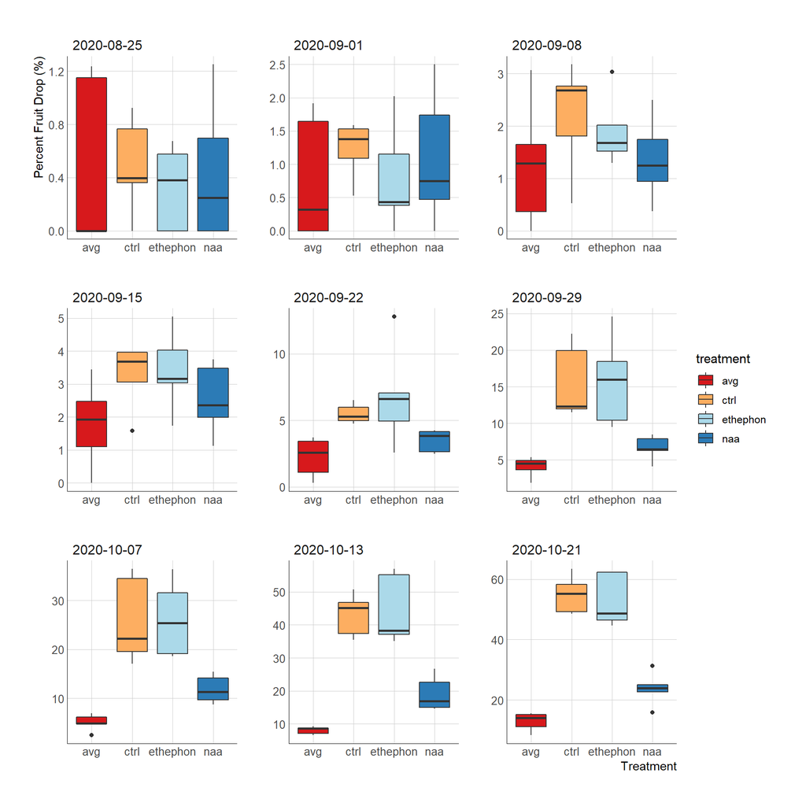

## ANOVA Assumptions

```r
drops.aov <- aov(drops ~ treatment*date, data = dropsLong)
summary.aov(drops.aov)
```

```
##                 Df Sum Sq Mean Sq F value Pr(>F)
## treatment        3   5771    1924   41.10 <2e-16 ***
## date             1  23468   23468  501.46 <2e-16 ***
## treatment:date   3   6731    2244   47.94 <2e-16 ***
## Residuals      172   8050      47
## ---
## Signif. codes:  0 '***' 0.001 '**' 0.01 '*' 0.05 '.' 0.1 ' ' 1
```

To check ANOVA assumptions an ANOVA model was built on each date…

```r
dropSep1.aov <- aov(perDropSep1 ~ treatment, data = drops)
```

Shapiro Wilkes test was done on the residuals to determine whether the data was normally distributed…

```r
dropSep1.resid <- residuals(object = dropSep1.aov)
shapiro.test(x = dropSep1.resid)
```

Then Levene’s test was done to check for homogeneity of variance…

```r
leveneTest(perDropSep1 ~ treatment, data = drops)
```

The following are the p-values for these test statics on each date…

### **Aug. 25**

```r
shapiro.test(x = dropAug25.resid)
```

```
##
##  Shapiro-Wilk normality test
##
## data:  dropAug25.resid
## W = 0.89092, p-value = 0.02796
```

p<0.05 and therefore data was transformed via square root…

```r
shapiro.test(x = sqrt(dropAug25.resid))
```

```
##
##  Shapiro-Wilk normality test
##
## data:  sqrt(dropAug25.resid)
## W = 0.93429, p-value = 0.5232
```

The data was now normally distributed and levene’s test was not significant…

```r
leveneTest(perDropAug25 ~ treatment, data = drops)
```

```
## Levene's Test for Homogeneity of Variance (center = median)
##       Df F value Pr(>F)
## group  3  0.3567  0.785
##       16
```

### **Sep. 1**

```r
shapiro.test(x = dropSep1.resid)
```

```
##
##  Shapiro-Wilk normality test
##
## data:  dropSep1.resid
## W = 0.93081, p-value = 0.16
```

```r
leveneTest(perDropSep1 ~ treatment, data = drops)
```

```
## Levene's Test for Homogeneity of Variance (center = median)
##       Df F value Pr(>F)
## group  3  0.5689 0.6435
##       16
```

### **Sep. 8**

```r
shapiro.test(x = dropSep8.resid)
```

```
##
##  Shapiro-Wilk normality test
##
## data:  dropSep8.resid
## W = 0.9898, p-value = 0.9979
```

```r
leveneTest(perDropSep8 ~ treatment, data = drops)
```

```
## Levene's Test for Homogeneity of Variance (center = median)
##       Df F value Pr(>F)
## group  3   0.368 0.7771
##       16
```

### **Sep. 15**

```r
shapiro.test(x = dropSep15.resid)
```

```
##
##  Shapiro-Wilk normality test
##
## data:  dropSep15.resid
## W = 0.94551, p-value = 0.304
```

```r
leveneTest(perDropSep15 ~ treatment, data = drops)
```

```
## Levene's Test for Homogeneity of Variance (center = median)
##       Df F value Pr(>F)
## group  3  0.1365 0.9368
##       16
```

### **Sep. 22**

Data was not normally distributed…

```r
shapiro.test(x = dropSep22.resid)
```

```
##
##  Shapiro-Wilk normality test
##
## data:  dropSep22.resid
## W = 0.87379, p-value = 0.01371
```

Taking the negative square root normalized the data…

```r
shapiro.test(x = (dropSep22.resid)^(-.5))
```

```
##
##  Shapiro-Wilk normality test
##
## data:  (dropSep22.resid)^(-0.5)
## W = 0.98287, p-value = 0.9787
```

Variances were equal among groups…

```r
leveneTest(perDropSep22 ~ treatment, data = drops)
```

```
## Levene's Test for Homogeneity of Variance (center = median)
##       Df F value Pr(>F)
## group  3  1.9196 0.1671
##       16
```

### **Sep. 29**

```r
shapiro.test(x = dropSep29.resid)
```

```
##
##  Shapiro-Wilk normality test
##
## data:  dropSep29.resid
## W = 0.96657, p-value = 0.6814
```

```r
leveneTest(perDropSep29 ~ treatment, data = drops)
```

```
## Levene's Test for Homogeneity of Variance (center = median)
##       Df F value Pr(>F)
## group  3  1.8825 0.1732
##       16
```

### **Oct. 7**

```r
shapiro.test(x = dropOct7.resid)
```

```
##
##  Shapiro-Wilk normality test
##
## data:  dropOct7.resid
## W = 0.9582, p-value = 0.5086
```

```r
leveneTest(perDropOct7 ~ treatment, data = drops)
```

```
## Levene's Test for Homogeneity of Variance (center = median)
##       Df F value  Pr(>F)
## group  3  2.7577 0.07634 .
##       16
## ---
## Signif. codes:  0 '***' 0.001 '**' 0.01 '*' 0.05 '.' 0.1 ' ' 1
```

### **Oct. 13**

```r
shapiro.test(x = dropOct13.resid)
```

```
##
##  Shapiro-Wilk normality test
##
## data:  dropOct13.resid
## W = 0.96241, p-value = 0.5931
```

```r
leveneTest(perDropOct13 ~ treatment, data = drops)
```

```
## Levene's Test for Homogeneity of Variance (center = median)
##       Df F value Pr(>F)
## group  3  1.5125 0.2494
##       16
```

### **Oct. 21**

```r
shapiro.test(x = dropOct21.resid)
```

```
##
##  Shapiro-Wilk normality test
##
## data:  dropOct21.resid
## W = 0.93789, p-value = 0.2186
```

```r
leveneTest(perDropOct21 ~ treatment, data = drops)
```

```
## Levene's Test for Homogeneity of Variance (center = median)
##       Df F value Pr(>F)
## group  3  1.0151 0.4119
##       16
```

Following are diagnostic plots for the residuals to assess homogeneity of variance and a QQ plot for normality:

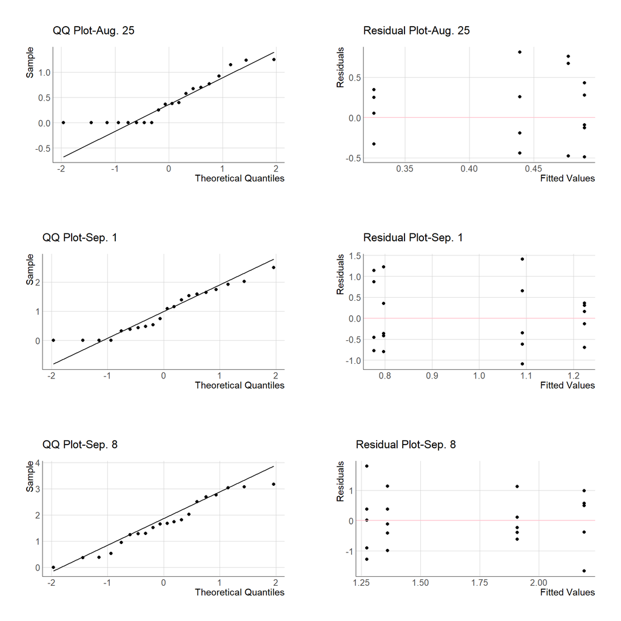

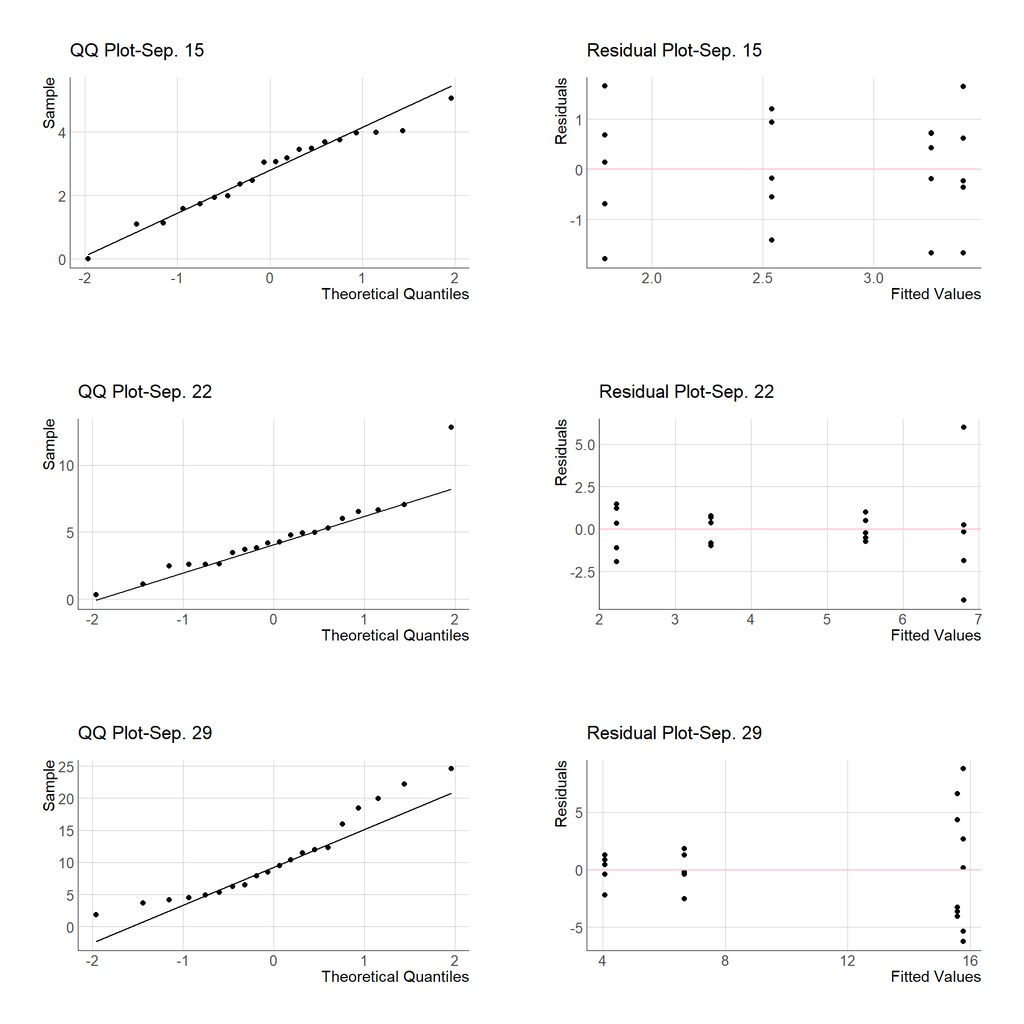

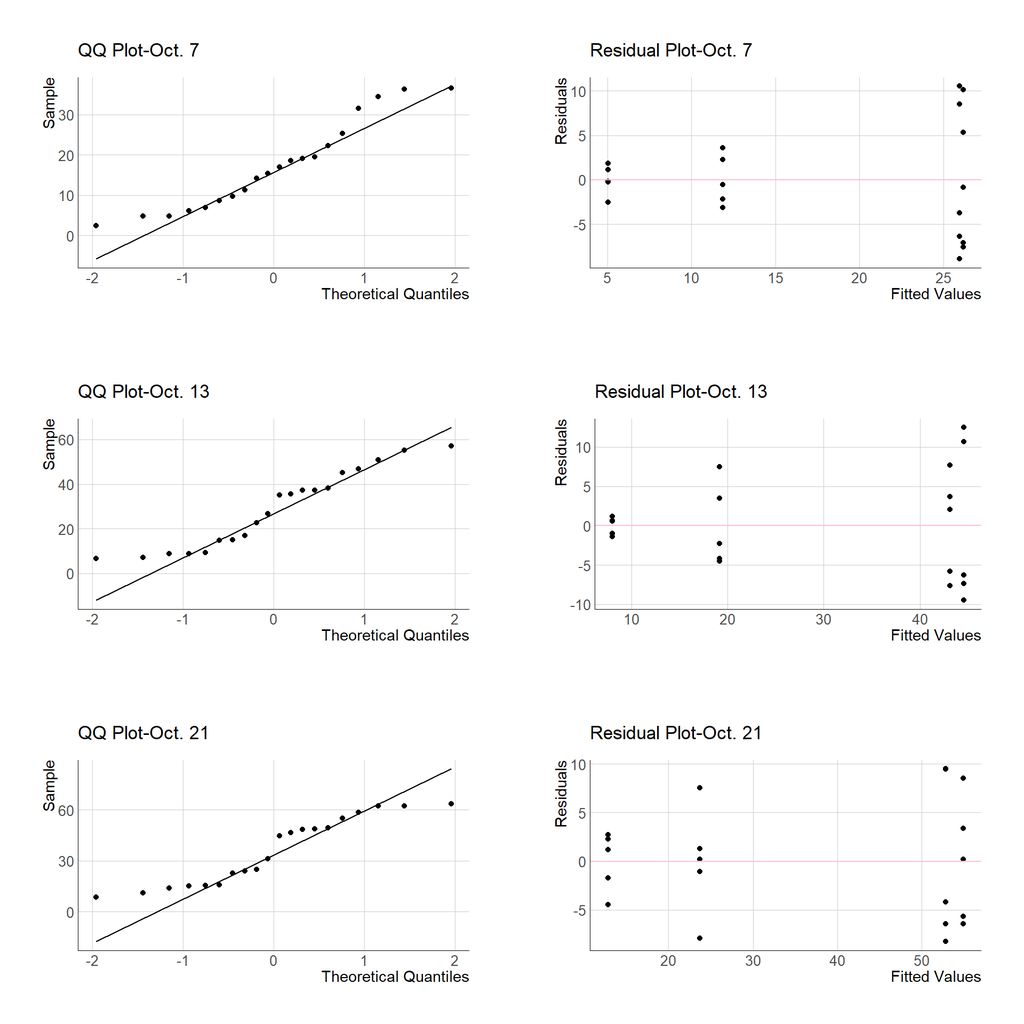

## Mean Separation

After transformation of drop data on Aug. 25 and Sep. 22 mean separation was done from the ANOVA model using Tukey’s HSD, below is the resulting p-values for each pairwise comparison on each measurement date…

### **Aug. 25**

```r
dropAug25.norm.aov <- aov(sqrt(perDropAug25) ~ treatment, data = drops)
TukeyHSD(dropAug25.norm.aov)
```

```
##   Tukey multiple comparisons of means
##     95% family-wise confidence level
##
## Fit: aov(formula = sqrt(perDropAug25) ~ treatment, data = drops)
##
## $treatment
##                       diff        lwr       upr     p adj
## ctrl-avg       0.176810670 -0.6880113 1.0416327 0.9351848
## ethephon-avg   0.002640466 -0.8621815 0.8674625 0.9999997
## naa-avg        0.053669776 -0.8111522 0.9184918 0.9979263
## ethephon-ctrl -0.174170204 -1.0389922 0.6906518 0.9377790
## naa-ctrl      -0.123140893 -0.9879629 0.7416811 0.9763872
## naa-ethephon   0.051029311 -0.8137927 0.9158513 0.9982152
```

### **Sep. 1**

```r
TukeyHSD(dropSep1.aov)
```

```
##   Tukey multiple comparisons of means
##     95% family-wise confidence level
##
## Fit: aov(formula = perDropSep1 ~ treatment, data = drops)
##
## $treatment
##                      diff       lwr      upr     p adj
## ctrl-avg       0.44701428 -1.045594 1.939623 0.8265776
## ethephon-avg   0.02054512 -1.472064 1.513154 0.9999771
## naa-avg        0.31535686 -1.177252 1.807966 0.9291666
## ethephon-ctrl -0.42646917 -1.919078 1.066140 0.8453716
## naa-ctrl      -0.13165742 -1.624266 1.360951 0.9941298
## naa-ethephon   0.29481174 -1.197797 1.787420 0.9409901
```

### **Sep. 8**

```r
TukeyHSD(dropSep8.aov)
```

```
##   Tukey multiple comparisons of means
##     95% family-wise confidence level
##
## Fit: aov(formula = perDropSep8 ~ treatment, data = drops)
##
## $treatment
##                      diff       lwr       upr     p adj
## ctrl-avg       0.91944438 -0.813882 2.6527707 0.4505184
## ethephon-avg   0.63600299 -1.097323 2.3693294 0.7235561
## naa-avg        0.08804642 -1.645280 1.8213728 0.9988576
## ethephon-ctrl -0.28344138 -2.016768 1.4498850 0.9650434
## naa-ctrl      -0.83139795 -2.564724 0.9019284 0.5333265
## naa-ethephon  -0.54795657 -2.281283 1.1853698 0.8027012
```

### **Sep. 15**

```r
TukeyHSD(dropSep15.aov)
```

```
##   Tukey multiple comparisons of means
##     95% family-wise confidence level
##
## Fit: aov(formula = perDropSep15 ~ treatment, data = drops)
##
## $treatment
##                     diff        lwr      upr     p adj
## ctrl-avg       1.4686439 -0.6395870 3.576875 0.2313463
## ethephon-avg   1.6142386 -0.4939923 3.722470 0.1680489
## naa-avg        0.7522134 -1.3560175 2.860444 0.7399566
## ethephon-ctrl  0.1455947 -1.9626363 2.253826 0.9971518
## naa-ctrl      -0.7164305 -2.8246614 1.391800 0.7668124
## naa-ethephon  -0.8620252 -2.9702561 1.246206 0.6535150
```

### **Sep. 22**

```r
dropSep22.norm.aov <- aov((perDropSep22)^(-.5) ~ treatment, data = drops)
TukeyHSD(dropSep22.norm.aov)
```

```
##   Tukey multiple comparisons of means
##     95% family-wise confidence level
##
## Fit: aov(formula = (perDropSep22)^(-0.5) ~ treatment, data = drops)
##
## $treatment
##                       diff        lwr        upr     p adj
## ctrl-avg      -0.457408868 -0.9613452 0.04652746 0.0821725
## ethephon-avg  -0.462659426 -0.9665957 0.04127690 0.0777744
## naa-avg       -0.338349780 -0.8422861 0.16558654 0.2585271
## ethephon-ctrl -0.005250557 -0.5091869 0.49868577 0.9999901
## naa-ctrl       0.119059088 -0.3848772 0.62299541 0.9046776
## naa-ethephon   0.124309645 -0.3796267 0.62824597 0.8933385
```

### **Sep. 29**

```r
TukeyHSD(dropSep29.aov)
```

```
##   Tukey multiple comparisons of means
##     95% family-wise confidence level
##
## Fit: aov(formula = perDropSep29 ~ treatment, data = drops)
##
## $treatment
##                     diff        lwr       upr     p adj
## ctrl-avg      11.5161503   4.013384 19.018916 0.0023116
## ethephon-avg  11.7150632   4.212297 19.217829 0.0019826
## naa-avg        2.5876642  -4.915102 10.090430 0.7588819
## ethephon-ctrl  0.1989128  -7.303853  7.701679 0.9998365
## naa-ctrl      -8.9284861 -16.431252 -1.425720 0.0171350
## naa-ethephon  -9.1273989 -16.630165 -1.624633 0.0147086
```

### **Oct. 7**

```r
TukeyHSD(dropOct7.aov)
```

```
##   Tukey multiple comparisons of means
##     95% family-wise confidence level
##
## Fit: aov(formula = perDropOct7 ~ treatment, data = drops)
##
## $treatment
##                      diff        lwr       upr     p adj
## ctrl-avg       20.9344800   9.829779 32.039181 0.0003149
## ethephon-avg   21.1737223  10.069022 32.278423 0.0002794
## naa-avg         6.8203347  -4.284366 17.925035 0.3285528
## ethephon-ctrl   0.2392423 -10.865458 11.343943 0.9999122
## naa-ctrl      -14.1141453 -25.218846 -3.009445 0.0107325
## naa-ethephon  -14.3533876 -25.458088 -3.248687 0.0094708
```

### **Oct. 13**

```r
TukeyHSD(dropOct13.aov)
```

```
##   Tukey multiple comparisons of means
##     95% family-wise confidence level
##
## Fit: aov(formula = perDropOct13 ~ treatment, data = drops)
##
## $treatment
##                     diff        lwr       upr     p adj
## ctrl-avg       35.087916  22.795301  47.38053 0.0000023
## ethephon-avg   36.504841  24.212227  48.79746 0.0000014
## naa-avg        11.128640  -1.163974  23.42125 0.0831997
## ethephon-ctrl   1.416925 -10.875689  13.70954 0.9871571
## naa-ctrl      -23.959276 -36.251890 -11.66666 0.0002212
## naa-ethephon  -25.376201 -37.668815 -13.08359 0.0001182
```

### **Oct. 21**

```r
TukeyHSD(dropOct21.aov)
```

```
##   Tukey multiple comparisons of means
##     95% family-wise confidence level
##
## Fit: aov(formula = perDropOct21 ~ treatment, data = drops)
##
## $treatment
##                     diff         lwr        upr     p adj
## ctrl-avg       42.158560  30.8657819  53.451339 0.0000001
## ethephon-avg   40.045329  28.7525505  51.338107 0.0000001
## naa-avg        10.900733  -0.3920454  22.193512 0.0604109
## ethephon-ctrl  -2.113231 -13.4060099   9.179547 0.9491130
## naa-ctrl      -31.257827 -42.5506058 -19.965049 0.0000035
## naa-ethephon  -29.144596 -40.4373744 -17.851817 0.0000084
```

Below is the resulting figure…

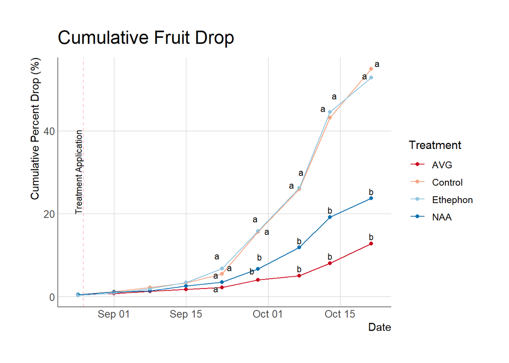